# Final Project Data 608

Anil Akyildirim

5/6/2020

# 1 Introduction

Google Analytics is a well known Web Analytics Platform that allows businesses to track the consumer acquisition, engagement, beahvior and conversion through their website. Even though it might be considered as a basic platform, it follows the standard Data Science process where it collects data from website user’s browser, transforms and cleans based on business input and provides analysis of the data via the Google Analytics User Interface. In my final project, I decided to leverage Google Analytics Data to solve one of the most commont problems Marketing Departments within businesses solve everyday. The high level problem statement is “How should our business allocate their Marketing Budget on weekly, daily, yearly or even daily basis?” . In order to explore this problem further, we would need to look at the Google Analytics Data in detail for Unique visitors, Sessions, Channel Grouping, Transaction Revenue and New vs Returning Consumer. Our purpose of this analysis is to provide actionable insights to the marketing team so they can use their budget based on the business conversion goals. Instead of using a Power Point Presentation, we will build an engaging analysis and shiny app that works with our Google Analytics Data.

# 2 About the Data

##Data Fields

**fullVisitorId- A unique identifier for each user of the Google Merchandise Store.**

**channelGrouping - The channel via which the user came to the Store.**

**date - The date on which the user visited the Store.**

**device - The specifications for the device used to access the Store.**

**geoNetwork - This section contains information about the geography of the user.**

**socialEngagementType - Engagement type, either “Socially Engaged” or “Not Socially Engaged”.**

**totals - This section contains aggregate values across the session.**

**trafficSource - This section contains information about the Traffic Source from which the session originated.**

**visitId - An identifier for this session. This is part of the value usually stored as the _utmb cookie. This is only unique to the user. For a completely unique ID, you should use a combination of fullVisitorId and visitId.**

**visitNumber - The session number for this user. If this is the first session, then this is set to 1.**

**visitStartTime - The timestamp (expressed as POSIX time).**

**hits - This row and nested fields are populated for any and all types of hits. Provides a record of all page visits.**

**customDimensions - This section contains any user-level or session-level custom dimensions that are set for a session. This is a repeated field and has an entry for each dimension that is set.**

**totals - This set of columns mostly includes high-level aggregate data.**

# 3 Data Collection

## 3.1 Load Libraries

```r
library("readxl")
library(shiny)
#library(googleAuthR)        # To prompt for authentication by the user
#library(googleAnalyticsR)   # For the pulling of the data
library(tidyverse)
library(scales)
```

```r
library(googleCharts)
library(dplyr)
library(lubridate)
require(shinydashboard)
library(ggplot2)
library(plotly)
library(stringr)
library(knitr)
library(kableExtra)
library(knitr)
library(corrplot)
library(ggplot2)
library(jsonlite)
library(scales)
library(lubridate)
library(repr)
library(ggrepel)
library(gridExtra)
library(tidyr)
library(psych)
library(ggpubr)
library(ggcorrplot)
```

For this purpose of this project, we will only use the train data and will not touch the test data provided by Kaggle.

```r
ga_train <- read.csv("train.csv")
```

# 4 Data Cleaning and Transformation

As we can see our dataset is a mess. It is the raw data that is pulled in from Big Query in csv format and needs to be cleaned in order for us to perform any analysis and visualization. The columns device, geoNetwork, totals and Traffic Source has multiple key value pairs.

```r
#JSON columns are "device", "geoNetwork", "totals", "trafficSource"

tr_device <- paste("[", paste(ga_train$device, collapse = ","), "]") %>% fromJSON(flatten = T)
tr_geoNetwork <- paste("[", paste(ga_train$geoNetwork, collapse = ","), "]") %>% fromJSON(flatten = T)
tr_totals <- paste("[", paste(ga_train$totals, collapse = ","), "]") %>% fromJSON(flatten = T)
tr_trafficSource <- paste("[", paste(ga_train$trafficSource, collapse = ","), "]") %>% fromJSON(flatten = T)


#Combine to make the full training and test sets
ga_train <- ga_train %>%
    cbind(tr_device, tr_geoNetwork, tr_totals, tr_trafficSource) %>%
    select(-device, -geoNetwork, -totals, -trafficSource)


#Remove temporary tr_ and te_ sets
rm(tr_device)
rm(tr_geoNetwork)
rm(tr_totals)
rm(tr_trafficSource)


# convert some character variables to categorical variables
factorVars <- c("channelGrouping", "browser", "operatingSystem", "deviceCategory", "country")
ga_train[, factorVars] <- lapply(ga_train[, factorVars], as.factor)

#converting the date variable from integer to the date format
ga_train$date <- ymd(ga_train$date)

#converting character variables into numeric
numVars <- c("visits", "hits", "bounces", "pageviews", "newVisits")
ga_train[, numVars] <- lapply(ga_train[, numVars], as.integer)
ga_train$transactionRevenue <- as.numeric(ga_train$transactionRevenue)

#converting visit start times to POSIXct
ga_train$visitStartTime <- as.POSIXct(ga_train$visitStartTime, tz="UTC", origin='1970-01-01')
```

Let’s look at the structure and descriptive statistic of our data.

```r
# look at descriptive statistics
metastats <- data.frame(describe(ga_train))
```

[output not shown]

[output cut: 36 more lines]

[output not shown]

[output not shown]

[output cut: 36 more lines]

[output not shown]

```r
metastats <- tibble::rownames_to_column(metastats, "STATS")
metastats["pct_missing"] <- round(metastats["n"]/903653, 3)
head(metastats)
```

```
##                  STATS vars      n         mean           sd          min
## 1      channelGrouping    1 903653          NaN           NA          Inf
## 2                 date    2 903653          NaN           NA          Inf
## 3        fullVisitorId    3 903653 4.505845e+18 3.071128e+18 4.823595e+12
## 4            sessionId    4 903653          NaN           NA          Inf
## 5 socialEngagementType    5 903653          NaN           NA          Inf
## 6              visitId    6 903653 1.485007e+09 9.022124e+06 1.470035e+09
##            max        range           se pct_missing
## 1         -Inf         -Inf           NA           1
## 2         -Inf         -Inf           NA           1
## 3 5.198308e+19 5.198307e+19 3.230703e+15           1
## 4         -Inf         -Inf           NA           1
## 5         -Inf         -Inf           NA           1
## 6 1.501657e+09 3.162238e+07 9.490911e+03           1
```

```r
#summary of the dataset
summary(ga_train)
```

```
##        channelGrouping        date            fullVisitorId
##  Organic Search:381561   Min.   :2016-08-01   Min.   :4.824e+12
##  Social        :226117   1st Qu.:2016-10-27   1st Qu.:1.593e+18
##  Direct        :143026   Median :2017-01-09   Median :4.388e+18
##  Referral      :104838   Mean   :2017-01-20   Mean   :4.506e+18
##  Paid Search   : 25326   3rd Qu.:2017-04-21   3rd Qu.:7.195e+18
##  Affiliates    : 16403   Max.   :2017-08-01   Max.   :5.198e+19
##  (Other)       :  6382
##                           sessionId                socialEngagementType
##  0011338928267756760_1471848731:     2   Not Socially Engaged:903653
##  0014884852016449602_1483257533:     2
##  0019612470994343873_1496731675:     2
##  0031542961723593073_1495261490:     2
##  0039798900163330977_1485331011:     2
##  0047064119019485310_1480924286:     2
##  (Other)                       :903641
##     visitId           visitNumber      visitStartTime
##  Min.   :1.470e+09   Min.   :  1.000   Min.   :2016-08-01 07:00:12
##  1st Qu.:1.478e+09   1st Qu.:  1.000   1st Qu.:2016-10-27 09:39:29
##  Median :1.484e+09   Median :  1.000   Median :2017-01-09 08:02:14
##  Mean   :1.485e+09   Mean   :  2.265   Mean   :2017-01-21 14:01:30
##  3rd Qu.:1.493e+09   3rd Qu.:  1.000   3rd Qu.:2017-04-21 07:12:42
##  Max.   :1.502e+09   Max.   :395.000   Max.   :2017-08-02 06:59:53
##
##               browser       browserVersion     browserSize
##  Chrome           :620364   Length:903653      Length:903653
##  Safari           :182245   Class :character   Class :character
##  Firefox          : 37069   Mode  :character   Mode  :character
##  Internet Explorer: 19375
##  Edge             : 10205
##  Android Webview  :  7865
##  (Other)          : 26530
##   operatingSystem   operatingSystemVersion  isMobile       mobileDeviceBranding
##  Windows  :350072   Length:903653          Mode :logical   Length:903653
##  Macintosh:253938   Class :character       FALSE:664530    Class :character
##  Android  :123892   Mode  :character       TRUE :239123    Mode  :character
##  iOS      :107665
##  Linux    : 35034
##  Chrome OS: 26337
##  (Other)  :  6715
```

[output cut: 81 more lines]

```
##  Length:903653         Length:903653          Length:903653
##  Class :character      Class :character       Class :character
##  Mode  :character      Mode  :character       Mode  :character
##
##
##
##
##  adwordsClickInfo.isVideoAd
##  Mode :logical
##  FALSE:21460
##  NA's :882193
##
##
##
##
```

Based on the Channel Grouping, we are acquiring majority of the users via Organic Search, followed by Social. Majority of the visitors are using Chrome as their browser, using Desktop as a device and are from United Staes.

Let’s look at the missing values in more detail.

```r
colSums(is.na(ga_train))
```

```
##                     channelGrouping                                date
##                                   0                                   0
##                       fullVisitorId                           sessionId
##                                   0                                   0
##                socialEngagementType                             visitId
##                                   0                                   0
##                         visitNumber                      visitStartTime
##                                   0                                   0
##                             browser                      browserVersion
##                                   0                                   0
##                         browserSize                     operatingSystem
##                                   0                                   0
##              operatingSystemVersion                            isMobile
##                                   0                                   0
##                mobileDeviceBranding                   mobileDeviceModel
##                                   0                                   0
##                 mobileInputSelector                    mobileDeviceInfo
##                                   0                                   0
##           mobileDeviceMarketingName                        flashVersion
##                                   0                                   0
##                            language                        screenColors
##                                   0                                   0
##                    screenResolution                      deviceCategory
##                                   0                                   0
##                           continent                        subContinent
##                                   0                                   0
##                             country                              region
##                                   0                                   0
##                               metro                                city
##                                   0                                   0
##                              cityId                       networkDomain
##                                   0                                   0
##                            latitude                           longitude
##                                   0                                   0
##                     networkLocation                              visits
##                                   0                                   0
##                                hits                           pageviews
##                                   0                                 100
##                             bounces                           newVisits
##                              453023                              200593
##                  transactionRevenue                            campaign
##                              892138                                   0
##                              source                              medium
##                                   0                                   0
##                             keyword                        isTrueDirect
##                              502929                              629648
##                        referralPath                           adContent
##                              572712                              892707
##                        campaignCode adwordsClickInfo.criteriaParameters
##                              903652                                   0
##               adwordsClickInfo.page               adwordsClickInfo.slot
##                              882193                              882193
##              adwordsClickInfo.gclId      adwordsClickInfo.adNetworkType
##                              882092                              882193
##          adwordsClickInfo.isVideoAd
##                              882193
```

We have a lot of missing values in campaigncode, transactionrevenue and some other variables. For the purpose of this project, we wont be handling these missing values. As we can see Channel Grouping variable which gives us the variety of Marketing Channels that we acquire the users from dont have any missing values along with sessionid, visit number.

```r
#Let's look at our columns
head(ga_train)
```

```
##   channelGrouping       date fullVisitorId                      sessionId
## 1  Organic Search 2016-09-02  1.131660e+18 1131660440785968503_1472830385
## 2  Organic Search 2016-09-02  3.773060e+17  377306020877927890_1472880147
## 3  Organic Search 2016-09-02  3.895546e+18 3895546263509774583_1472865386
## 4  Organic Search 2016-09-02  4.763447e+18 4763447161404445595_1472881213
## 5  Organic Search 2016-09-02  2.729444e+16   27294437909732085_1472822600
## 6  Organic Search 2016-09-02  2.938943e+18 2938943183656635653_1472807194
##   socialEngagementType    visitId visitNumber      visitStartTime    browser
## 1 Not Socially Engaged 1472830385           1 2016-09-02 15:33:05     Chrome
## 2 Not Socially Engaged 1472880147           1 2016-09-03 05:22:27    Firefox
## 3 Not Socially Engaged 1472865386           1 2016-09-03 01:16:26     Chrome
## 4 Not Socially Engaged 1472881213           1 2016-09-03 05:40:13 UC Browser
## 5 Not Socially Engaged 1472822600           2 2016-09-02 13:23:20     Chrome
## 6 Not Socially Engaged 1472807194           1 2016-09-02 09:06:34     Chrome
##                  browserVersion                   browserSize operatingSystem
```

[output cut: 104 more lines]

# 5 Data Exploration

Let’s further perform explanatory data analysis to this data set.

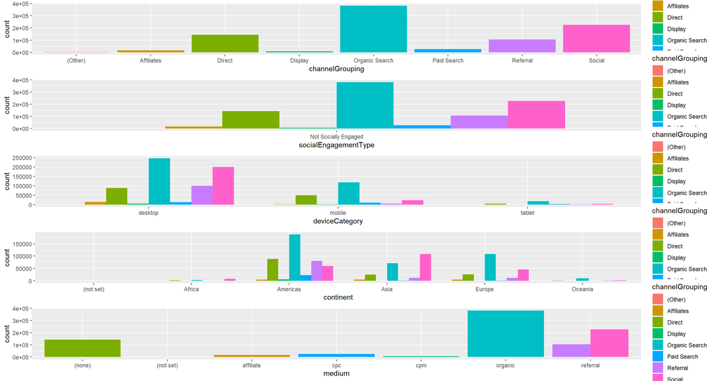

```r
c <- ga_train %>%
  ggplot(aes(channelGrouping)) +
  geom_bar(aes(fill=channelGrouping), position = position_dodge())


se <- ga_train %>%
  ggplot(aes(socialEngagementType)) +
  geom_bar(aes(fill=channelGrouping), position = position_dodge())


d <- ga_train %>%
  ggplot(aes(deviceCategory)) +
  geom_bar(aes(fill=channelGrouping), position = position_dodge())


co <- ga_train %>%
  ggplot(aes(continent)) +
  geom_bar(aes(fill=channelGrouping), position = position_dodge())



me <- ga_train %>%
  ggplot(aes(medium)) +
  geom_bar(aes(fill=channelGrouping), position = position_dodge())


ggarrange(c, se, d, co, me, nrow = 5)
```

Let’s look at Sessions and Transaction Revenue, one of the usual business goals of an ecommerce business.

```r
# Assign $0 value to the TransactionRevenu that has missing values.
ga_train$transactionRevenue[is.na(ga_train$transactionRevenue)] <- 0

y <- ga_train$transactionRevenue #saving original values in a vector
ga_train$transactionRevenue <- ga_train$transactionRevenue/1000000


ga_train %>% filter(transactionRevenue >0) %>% summarize('number of transactions'=n(), 'total revenues train set'=sum(transactionRevenue))
```

```
##   number of transactions total revenues train set
## 1                  11515                  1540071
```

We dont neccessarily need to see the transaction values that are 0 or less than $1,000

```r
range(ga_train %>% select(transactionRevenue) %>% filter(transactionRevenue !=0))
```

```
## [1]     0.01 23129.50
```

```r
ga_train %>% filter(transactionRevenue>=1000) %>% summarize('number of transactions with at least 1000 USD revenues'=n(), 'sum revenues of transactions with at least 1000 USD revenues'=sum(transactionRevenue))
```

```
##   number of transactions with at least 1000 USD revenues
## 1                                                    195
##   sum revenues of transactions with at least 1000 USD revenues
## 1                                                     418588.3
```

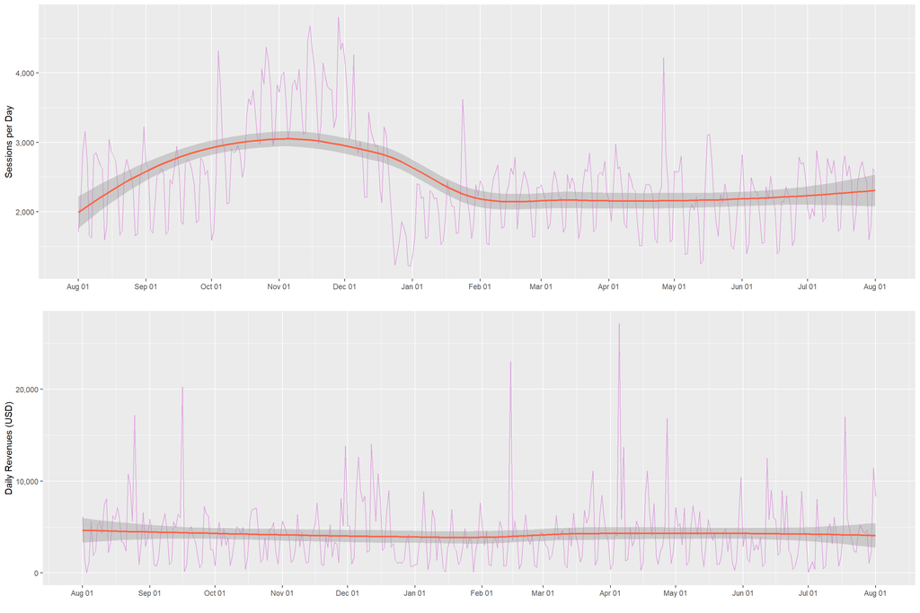

```r
z1 <- ga_train %>%
  group_by(date) %>%
  summarise(dailySessions = n()) %>%
  ggplot(aes(x=date, y=dailySessions)) + geom_line(col='plum') +
  scale_y_continuous(labels=comma) + geom_smooth(col='tomato') +
  labs(x="", y="Sessions per Day") + scale_x_date(date_breaks = "1 month", date_labels = "%b %d")

z2 <- ga_train %>%
  group_by(date) %>%
  summarise(dailyRevenue = sum(transactionRevenue)) %>%
  ggplot(aes(x=date, y=dailyRevenue)) + geom_line(col='plum') +
  scale_y_continuous(labels=comma) + geom_smooth(col='tomato') +
  labs(x="", y="Daily Revenues (USD)") + scale_x_date(date_breaks = "1 month", date_labels = "%b %d")

grid.arrange(z1,z2)
```

We can see that sessions have increased starting October and peaked in November, however went back to normal in January. When we compare the Daily Revenus within the same time frame we see that it stayed flat. This means, users are engaging with the Google eStore, however not contributing to the purchase.

Let’s analyze further to see when consumers are engaging with the website the most.

```r
# creating this function to plot the next two visualizations easily

plotSessions <- function(dataframe, factorVariable, topN=10) {
    var_col <- enquo(factorVariable)
    dataframe %>% count(!!var_col) %>% top_n(topN, wt=n) %>%
    ggplot(aes_(x=var_col, y=~n, fill=var_col)) +
    geom_bar(stat='identity')+
    scale_y_continuous(labels=comma)+
    labs(x="", y="number of sessions")+
    theme(legend.position="none")
    }

#also creating a function to plot transactionRevenue for a factorvariable
plotRevenue <- function(dataframe, factorVariable, topN=10) {
    var_col <- enquo(factorVariable)
    dataframe %>% group_by(!!var_col) %>% summarize(rev=sum(transactionRevenue)) %>% filter(rev>0) %>% top_n(topN, wt=rev) %>% ungroup() %>%
    ggplot(aes_(x=var_col, y=~rev, fill=var_col)) +
    geom_bar(stat='identity')+
    scale_y_continuous(labels=comma)+
    labs(x="", y="Revenues (USD)")+
    theme(legend.position="none")
    }
```

```r
# create weekday
ga_train$weekday <- wday(ga_train$date, label=TRUE)
```

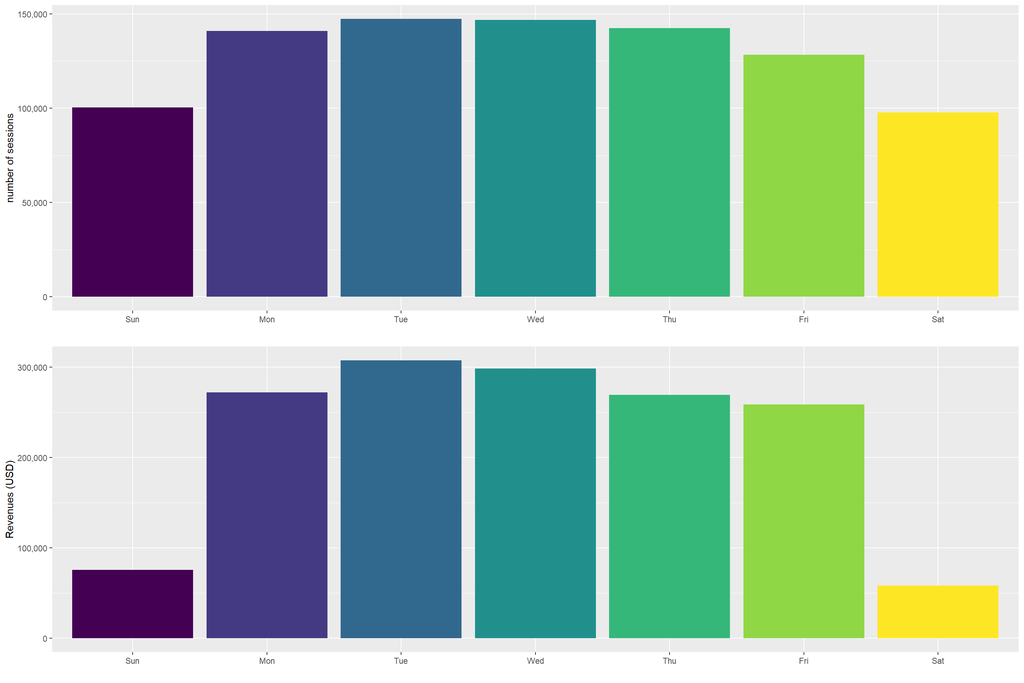

```r
options(repr.plot.height=4)
week1 <- plotSessions(ga_train, weekday)
week2 <- plotRevenue(ga_train, weekday)
grid.arrange(week1, week2)
```

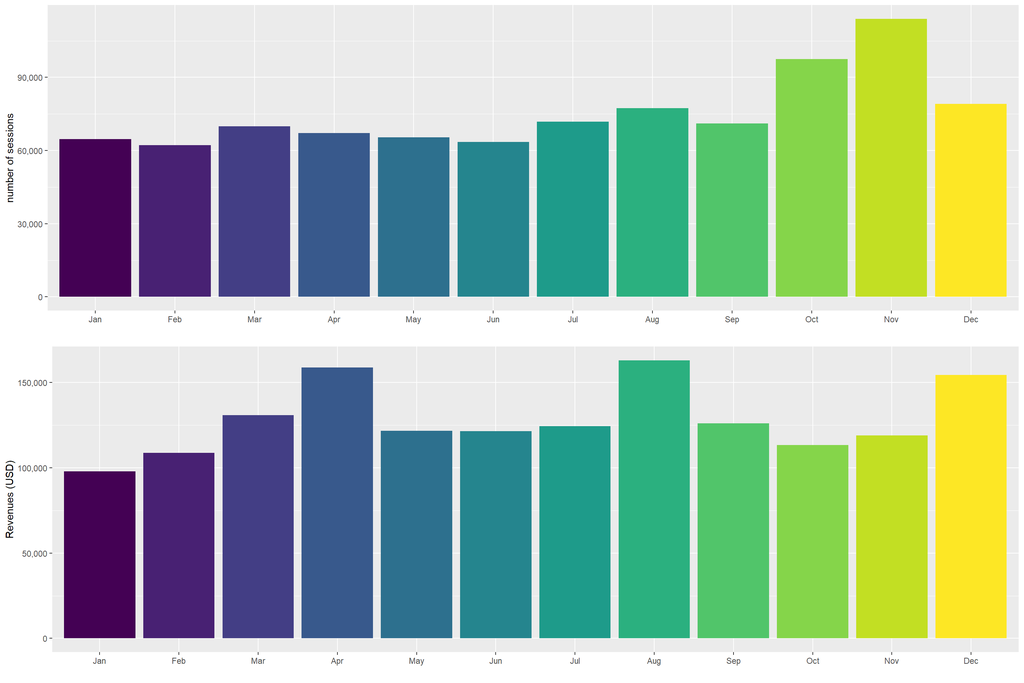

```r
ga_train$month <- month(ga_train$date, label=TRUE)


m1 <- plotSessions(ga_train, month, 12)
m2 <- plotRevenue(ga_train, month, 12)
grid.arrange(m1, m2)
```

Let’s look at our Marketing Channels and their contribution to the user engagement and Revenue since that is what we want to explore in terms of solving business problem.

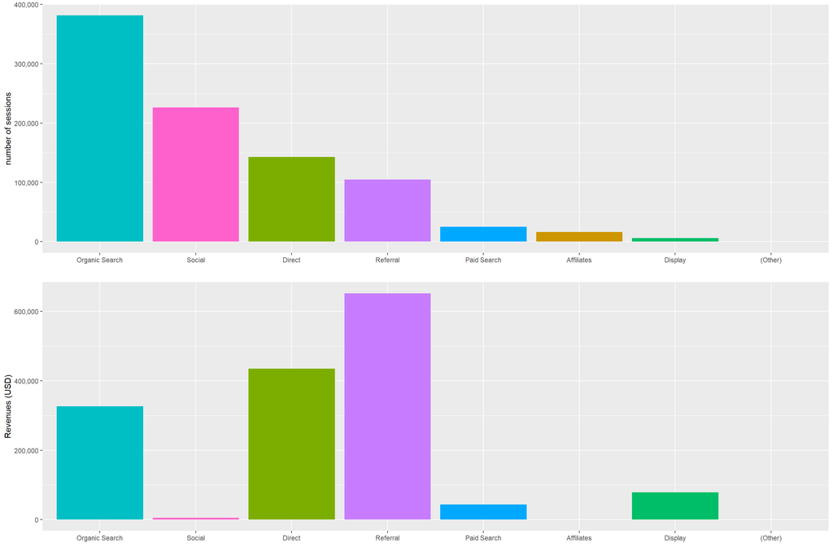

```r
#adding reordering of x manually
sessionOrder <- ga_train %>%
  count(channelGrouping) %>%
  top_n(10, wt=n) %>%
  arrange(desc(n))
sessionOrder <- sessionOrder$channelGrouping

channel1 <- plotSessions(ga_train, channelGrouping) + scale_x_discrete(limits=sessionOrder)
channel2 <- plotRevenue(ga_train, channelGrouping) + scale_x_discrete(limits=sessionOrder)
grid.arrange(channel1, channel2)
```

We can see that Organic Search has the highest number of Sessions however does not bring the biggest Revenue. Even thogh Referral has the 4th place in terms of User Engagement with the site, we see that it brings the highest contribution to the Revenue by far.

# 6 Conclusion

Even though as businesses we would like to have higher user acqusition and engagement, that doesnt always means that this meets their business goals. Depending on the website, business goals can mean content consumption, lead generation or higher purchase conversion which is the case in our analysis. We may not neccessarily want to have higher sessions but rather we would like to have higher unique visitors or higher revenue and allcote our Channel Distribution budgets accordingly.

References: https://www.youtube.com/watch?v=4Ht_vEXJ4wo : Create a Talking GA Shiny App, https://medium.com/compassred-data-blog/google-analytics-dashboards-in-r-shiny-fc8e0ebcef2c : Google Analytics Dashboard in R.